# Chapter 1

```r
knitr::opts_knit$set(root.dir = '~/Documents/Linear-Model-using-R')
```

# Chapter 1 Introduction

## 1.1 Before you start

## 1.2 Initial Data Analysis

```r
# install.packages("faraway")
library(faraway)
```

### import the dataset and have a first look at it

```r
# import the dataset called `pima` from the package
data(pima, package="faraway")
head(pima)
```

|  | pregnant | glucose | diastolic | triceps | insulin | bmi | diabetes | age | test |
| --- | --- | --- | --- | --- | --- | --- | --- | --- | --- |
| 1 | 6 | 148 | 72 | 35 | 0 | 33.6 | 0.627 | 50 | 1 |
| 2 | 1 | 85 | 66 | 29 | 0 | 26.6 | 0.351 | 31 | 0 |
| 3 | 8 | 183 | 64 | 0 | 0 | 23.3 | 0.672 | 32 | 1 |
| 4 | 1 | 89 | 66 | 23 | 94 | 28.1 | 0.167 | 21 | 0 |
| 5 | 0 | 137 | 40 | 35 | 168 | 43.1 | 2.288 | 33 | 1 |
| 6 | 5 | 116 | 74 | 0 | 0 | 25.6 | 0.201 | 30 | 0 |

```r
# alternative way to import data
# makes all data and functions that are included in the package available
require(faraway)
head(pima)
```

|  | pregnant | glucose | diastolic | triceps | insulin | bmi | diabetes | age | test |
| --- | --- | --- | --- | --- | --- | --- | --- | --- | --- |
| 1 | 6 | 148 | 72 | 35 | 0 | 33.6 | 0.627 | 50 | 1 |
| 2 | 1 | 85 | 66 | 29 | 0 | 26.6 | 0.351 | 31 | 0 |
| 3 | 8 | 183 | 64 | 0 | 0 | 23.3 | 0.672 | 32 | 1 |
| 4 | 1 | 89 | 66 | 23 | 94 | 28.1 | 0.167 | 21 | 0 |
| 5 | 0 | 137 | 40 | 35 | 168 | 43.1 | 2.288 | 33 | 1 |
| 6 | 5 | 116 | 74 | 0 | 0 | 25.6 | 0.201 | 30 | 0 |

### make numerical summaries

At this stage, we are looking for anything unusual or unexpected e.g. data-entry error

```r
# obtain numerical summaries
# summary function gives the usual univariate summary information
summary(pima)
```

```
    pregnant         glucose        diastolic         triceps         insulin           bmi
 Min.   : 0.000   Min.   :  0.0   Min.   :  0.00   Min.   : 0.00   Min.   :  0.0   Min.   : 0.00
 1st Qu.: 1.000   1st Qu.: 99.0   1st Qu.: 62.00   1st Qu.: 0.00   1st Qu.:  0.0   1st Qu.:27.30
 Median : 3.000   Median :117.0   Median : 72.00   Median :23.00   Median : 30.5   Median :32.00
 Mean   : 3.845   Mean   :120.9   Mean   : 69.11   Mean   :20.54   Mean   : 79.8   Mean   :31.99
 3rd Qu.: 6.000   3rd Qu.:140.2   3rd Qu.: 80.00   3rd Qu.:32.00   3rd Qu.:127.2   3rd Qu.:36.60
 Max.   :17.000   Max.   :199.0   Max.   :122.00   Max.   :99.00   Max.   :846.0   Max.   :67.10
    diabetes           age             test
 Min.   :0.0780   Min.   :21.00   Min.   :0.000
 1st Qu.:0.2437   1st Qu.:24.00   1st Qu.:0.000
 Median :0.3725   Median :29.00   Median :0.000
 Mean   :0.4719   Mean   :33.24   Mean   :0.349
 3rd Qu.:0.6262   3rd Qu.:41.00   3rd Qu.:1.000
 Max.   :2.4200   Max.   :81.00   Max.   :1.000
```

The 0 values in `diastolic` should not be correct as it means no blood pressure. (During the data analysis part, we need to have basic domain knowledge on the area or some common sense) So, we need to further investigate the variable by sorting them:

```r
sort(pima$diastolic)
```

```
  [1]   0   0   0   0   0   0   0   0   0   0   0   0   0   0   0   0   0   0   0   0   0   0   0   0   0   0
 [27]   0   0   0   0   0   0   0   0   0  24  30  30  38  40  44  44  44  44  46  46  48  48  48  48  48  50
 [53]  50  50  50  50  50  50  50  50  50  50  50  50  52  52  52  52  52  52  52  52  52  52  52  54  54  54
 [79]  54  54  54  54  54  54  54  54  55  55  56  56  56  56  56  56  56  56  56  56  56  56  58  58  58  58
[105]  58  58  58  58  58  58  58  58  58  58  58  58  58  58  58  58  58  60  60  60  60  60  60  60  60  60
[131]  60  60  60  60  60  60  60  60  60  60  60  60  60  60  60  60  60  60  60  60  60  60  60  60  60  60
[157]  60  60  61  62  62  62  62  62  62  62  62  62  62  62  62  62  62  62  62  62  62  62  62  62  62  62
[183]  62  62  62  62  62  62  62  62  62  62  62  64  64  64  64  64  64  64  64  64  64  64  64  64  64  64
[209]  64  64  64  64  64  64  64  64  64  64  64  64  64  64  64  64  64  64  64  64  64  64  64  64  64  64
[235]  64  64  65  65  65  65  65  65  65  66  66  66  66  66  66  66  66  66  66  66  66  66  66  66  66  66
[261]  66  66  66  66  66  66  66  66  66  66  66  66  66  68  68  68  68  68  68  68  68  68  68  68  68  68
[287]  68  68  68  68  68  68  68  68  68  68  68  68  68  68  68  68  68  68  68  68  68  68  68  68  68  68
[313]  68  68  68  68  68  68  70  70  70  70  70  70  70  70  70  70  70  70  70  70  70  70  70  70  70  70
[339]  70  70  70  70  70  70  70  70  70  70  70  70  70  70  70  70  70  70  70  70  70  70  70  70  70  70
[365]  70  70  70  70  70  70  70  70  70  70  70  72  72  72  72  72  72  72  72  72  72  72  72  72  72  72
[391]  72  72  72  72  72  72  72  72  72  72  72  72  72  72  72  72  72  72  72  72  72  72  72  72  72  72
[417]  72  72  72  74  74  74  74  74  74  74  74  74  74  74  74  74  74  74  74  74  74  74  74  74  74  74
[443]  74  74  74  74  74  74  74  74  74  74  74  74  74  74  74  74  74  74  74  74  74  74  74  74  74  74
[469]  74  74  74  75  75  75  75  75  75  75  75  76  76  76  76  76  76  76  76  76  76  76  76  76  76  76
[495]  76  76  76  76  76  76  76  76  76  76  76  76  76  76  76  76  76  76  76  76  76  76  76  76  78  78
[521]  78  78  78  78  78  78  78  78  78  78  78  78  78  78  78  78  78  78  78  78  78  78  78  78  78  78
[547]  78  78  78  78  78  78  78  78  78  78  78  78  78  78  78  78  78  80  80  80  80  80  80  80  80  80
[573]  80  80  80  80  80  80  80  80  80  80  80  80  80  80  80  80  80  80  80  80  80  80  80  80  80  80
[599]  80  80  80  80  80  82  82  82  82  82  82  82  82  82  82  82  82  82  82  82  82  82  82  82  82  82
[625]  82  82  82  82  82  82  82  82  82  84  84  84  84  84  84  84  84  84  84  84  84  84  84  84  84  84
[651]  84  84  84  84  84  84  85  85  85  85  85  85  86  86  86  86  86  86  86  86  86  86  86  86  86  86
[677]  86  86  86  86  86  86  86  88  88  88  88  88  88  88  88  88  88  88  88  88  88  88  88  88  88  88
[703]  88  88  88  88  88  88  90  90  90  90  90  90  90  90  90  90  90  90  90  90  90  90  90  90  90  90
[729]  90  90  92  92  92  92  92  92  92  92  94  94  94  94  94  94  95  96  96  96  96  98  98  98 100 100
[755] 100 102 104 104 106 106 106 108 108 110 110 110 114 122
```

From the data, it is obvious that 35 entries have value 0, which probably indicates that these 0s are used to indicate missing values. If we don’t change the correct form for these missing values, these values may affect the analysis. So, we can convert these 0s to NA inferring that these values are missing.

Thus, we set all 0s in `diastolic`, `glucose`, `triceps`, `insulin` and `bmi` to NA.

```r
# convert all the 0 values in 5 variables to NA
pima$diastolic[pima$diastolic==0] <- NA
pima$glucose[pima$glucose == 0] <- NA
pima$triceps[pima$triceps == 0] <- NA
pima$insulin[pima$insulin == 0] <- NA
pima$bmi[pima$bmi == 0] <- NA
```

Variable `test` is a categorical variable which means it is a `factor` variable.

```r
# convert the `test` variable to a factor variable; otherwise, this variable will be treated as a
# quantitative variable
pima$test <- factor(pima$test)
# give a summary table for test variable
summary(pima$test)
```

```
  0   1
500 268
```

We can convert the labels for factor variables to descriptive ones:

```r
#convert the levels of `test` variable to descriptive labels
levels(pima$test) <- c("negative","positive")
summary(pima)
```

```
    pregnant         glucose        diastolic         triceps         insulin            bmi
 Min.   : 0.000   Min.   : 44.0   Min.   : 24.00   Min.   : 7.00   Min.   : 14.00   Min.   :18.20
 1st Qu.: 1.000   1st Qu.: 99.0   1st Qu.: 64.00   1st Qu.:22.00   1st Qu.: 76.25   1st Qu.:27.50
 Median : 3.000   Median :117.0   Median : 72.00   Median :29.00   Median :125.00   Median :32.30
 Mean   : 3.845   Mean   :121.7   Mean   : 72.41   Mean   :29.15   Mean   :155.55   Mean   :32.46
 3rd Qu.: 6.000   3rd Qu.:141.0   3rd Qu.: 80.00   3rd Qu.:36.00   3rd Qu.:190.00   3rd Qu.:36.60
 Max.   :17.000   Max.   :199.0   Max.   :122.00   Max.   :99.00   Max.   :846.00   Max.   :67.10
                  NA's   :5       NA's   :35       NA's   :227     NA's   :374      NA's   :11
    diabetes           age              test
 Min.   :0.0780   Min.   :21.00   negative:500
 1st Qu.:0.2437   1st Qu.:24.00   positive:268
 Median :0.3725   Median :29.00
 Mean   :0.4719   Mean   :33.24
 3rd Qu.:0.6262   3rd Qu.:41.00
 Max.   :2.4200   Max.   :81.00
```

### graphic descriptions

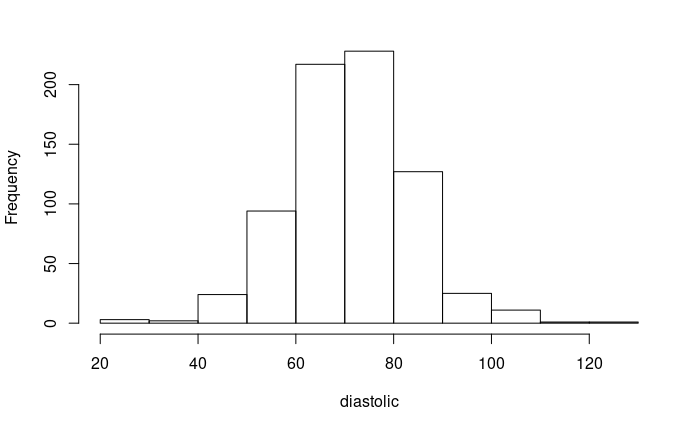

```r
#histogram with bins specified by r
hist(pima$diastolic, xlab="diastolic",main="")
```

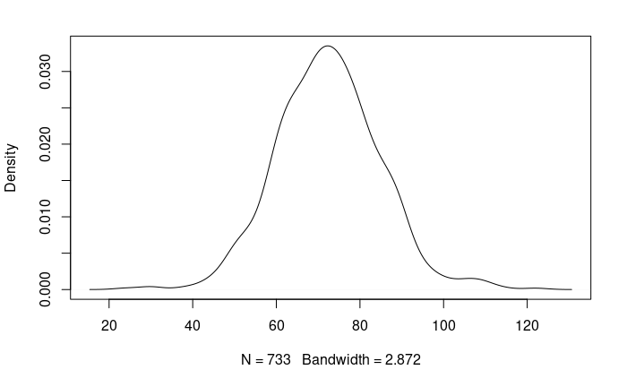

```r
# kernel estimate(density plot) of histogram
plot(density(pima$diastolic, na.rm = T),main="")
```

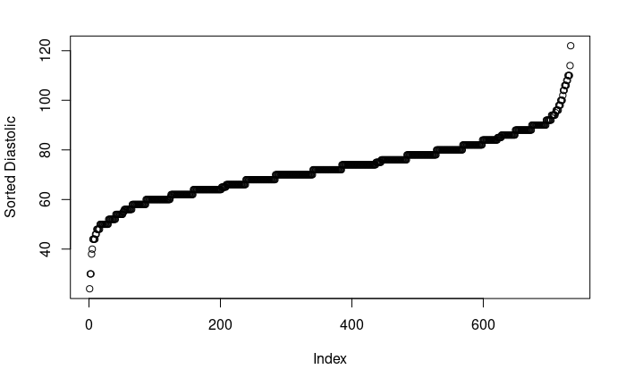

```r
plot(sort(pima$diastolic),ylab="Sorted Diastolic")
```

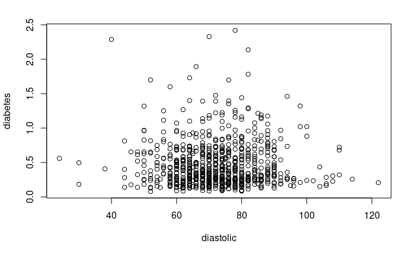

```r
# plot a scatterplot for diabetes against diastolic with the dataset pima
plot(diabetes~diastolic,pima)
```

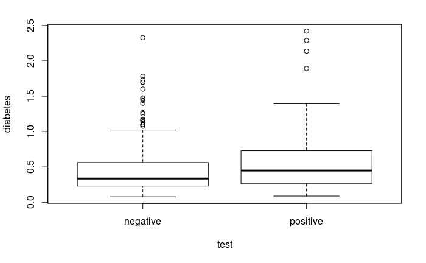

```r
# plot two boxplots for diabetes against both positive and negative cases
plot(diabetes~test,pima)
```

```r
# install.packages("ggplot2")
require(ggplot2)
```

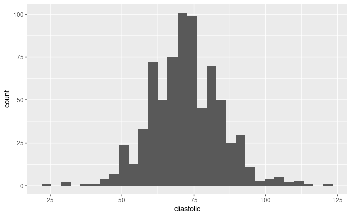

```r
# histogram
ggplot(pima, aes(x=diastolic))+geom_histogram()
```

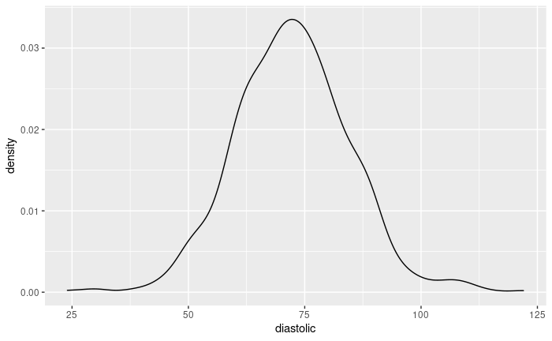

```r
# kernel estimate(density plot)
ggplot(pima, aes(x=diastolic))+geom_density()
```

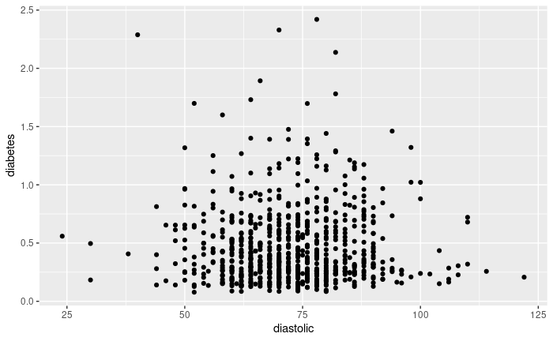

```r
# scatterplot
ggplot(pima, aes(x=diastolic,y=diabetes))+geom_point()
```

#### explanation of `ggplot`

`ggplot(<dataset_name>, aes(x = <x_axis>, y = <y_axis>, colour=<colour_name>, ...))+ <geo_plots()>+theme()+facet_grid()`

ggplot arguments: - dataset - aesthetic: specify x-axis, y-axis, shape of points, colour of graph, etc - geom_plots: different sorts of plots - theme: specify options on apperance of the plot - facet_grid: form a matrix of panels defined by row and column faceting variables

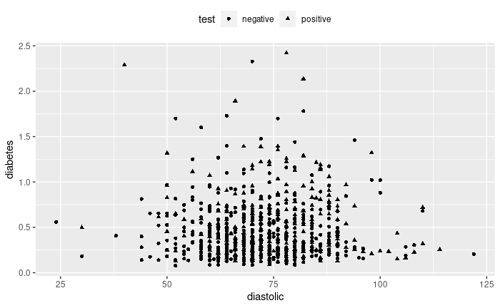

```r
# scatterplot with a legend on the top
ggplot(pima, aes(x=diastolic, y=diabetes, shape=test))+geom_point()+
    theme(legend.position="top", legend.direction="horizontal")
```

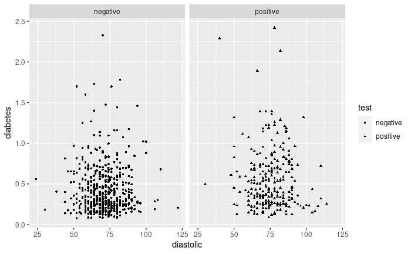

```r
# shape in aes function change the shape of points based on the values of test variable
ggplot(pima, aes(x=diastolic, y=diabetes, shape=test))+geom_point(size=1)+facet_grid(~test)
```

## 1.3 When to use linear models

Regression analysis have two main objectives:

1. prediction of future or unseen response given specified values of predictors.
2. Assessment of the effect of, or relations between, predictors and responses. If possible, we want to infer casual relationships.

## 1.4 History

### Use linear regression to find coefficients in physical science

```r
data(manilius, package="faraway")
head(manilius)
```

|  | arc | sinang | cosang | group |
| --- | --- | --- | --- | --- |
| 1 | 13.16667 | 0.8836 | -0.4682 | 1 |
| 2 | 13.13333 | 0.9996 | -0.0282 | 1 |
| 3 | 13.20000 | 0.9899 | 0.1421 | 1 |
| 4 | 14.25000 | 0.2221 | 0.9750 | 3 |
| 5 | 14.70000 | 0.0006 | 1.0000 | 3 |
| 6 | 13.01667 | 0.9308 | -0.3654 | 1 |

```r
lm1 <- lm(arc~sinang+cosang,data=manilius)
lm1$coef
```

```
(Intercept)      sinang      cosang
14.56162351 -1.50458123  0.09136504
```

### Use of linear regression to find coefficients in social science

```r
data(GaltonFamilies, package = "HistData")
head(GaltonFamilies)
```

|  | family | father | mother | midparentHeight | children | childNum | gender | childHeight |
| --- | --- | --- | --- | --- | --- | --- | --- | --- |
| 1 | 001 | 78.5 | 67.0 | 75.43 | 4 | 1 | male | 73.2 |
| 2 | 001 | 78.5 | 67.0 | 75.43 | 4 | 2 | female | 69.2 |
| 3 | 001 | 78.5 | 67.0 | 75.43 | 4 | 3 | female | 69.0 |
| 4 | 001 | 78.5 | 67.0 | 75.43 | 4 | 4 | female | 69.0 |
| 5 | 002 | 75.5 | 66.5 | 73.66 | 4 | 1 | male | 73.5 |
| 6 | 002 | 75.5 | 66.5 | 73.66 | 4 | 2 | male | 72.5 |

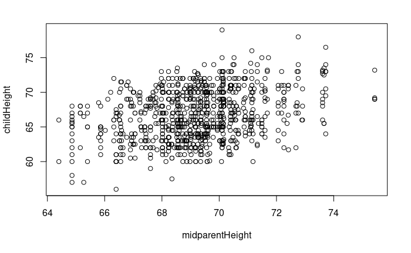

```r
plot(childHeight~midparentHeight, GaltonFamilies)
```

```r
lm2 <- lm(childHeight~GaltonFamilies$midparentHeight,data=GaltonFamilies)
coef(lm2)
```

```
                   (Intercept) GaltonFamilies$midparentHeight
                    22.6362405                      0.6373609
```

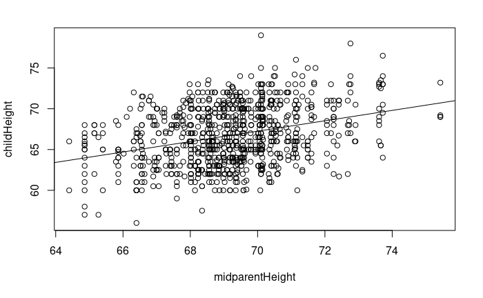

```r
plot(childHeight~midparentHeight, GaltonFamilies)
abline(lm2)
```

## Exercises

###1

```r
data("teengamb", package="faraway")
head(teengamb)
```

|  | sex | status | income | verbal | gamble |
| --- | --- | --- | --- | --- | --- |
| 1 | 1 | 51 | 2.00 | 8 | 0.0 |
| 2 | 1 | 28 | 2.50 | 8 | 0.0 |
| 3 | 1 | 37 | 2.00 | 6 | 0.0 |
| 4 | 1 | 28 | 7.00 | 4 | 7.3 |
| 5 | 1 | 65 | 2.00 | 8 | 19.6 |
| 6 | 1 | 61 | 3.47 | 6 | 0.1 |

##### numerical summary

```r
summary(teengamb)
```

```
      sex             status          income           verbal          gamble
 Min.   :0.0000   Min.   :18.00   Min.   : 0.600   Min.   : 1.00   Min.   :  0.0
 1st Qu.:0.0000   1st Qu.:28.00   1st Qu.: 2.000   1st Qu.: 6.00   1st Qu.:  1.1
 Median :0.0000   Median :43.00   Median : 3.250   Median : 7.00   Median :  6.0
 Mean   :0.4043   Mean   :45.23   Mean   : 4.642   Mean   : 6.66   Mean   : 19.3
 3rd Qu.:1.0000   3rd Qu.:61.50   3rd Qu.: 6.210   3rd Qu.: 8.00   3rd Qu.: 19.4
 Max.   :1.0000   Max.   :75.00   Max.   :15.000   Max.   :10.00   Max.   :156.0
```

```r
table(teengamb$sex)
```

```
 0  1
28 19
```

#### graphical summary

```r
par(mfrow=c(2,2))
plot(teengamb$sex,teengamb$gamble)
plot(teengamb$status,teengamb$gamble)
```

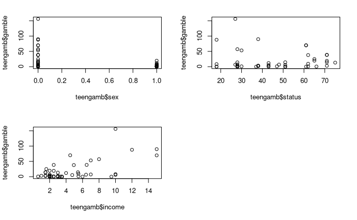

```r
plot(teengamb$income,teengamb$gamble)
plot(teengamb$verbal,teengamb$gamble)
```

```r
par(mfrow=c(2,2))
hist(teengamb$sex)
hist(teengamb$status)
```

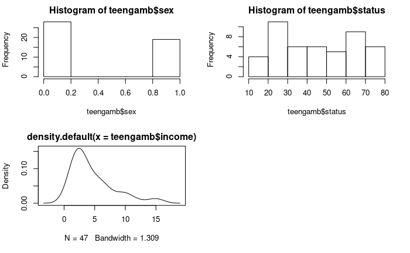

```r
plot(density(teengamb$income))
hist(teengamb$verbal)
```

### 2

```r
data("uswages",package="faraway")
head(uswages)
```

|  | wage | educ | exper | race | smsa | ne | mw | so | we | pt |
| --- | --- | --- | --- | --- | --- | --- | --- | --- | --- | --- |
| 6085 | 771.60 | 18 | 18 | 0 | 1 | 1 | 0 | 0 | 0 | 0 |
| 23701 | 617.28 | 15 | 20 | 0 | 1 | 0 | 0 | 0 | 1 | 0 |
| 16208 | 957.83 | 16 | 9 | 0 | 1 | 0 | 0 | 1 | 0 | 0 |
| 2720 | 617.28 | 12 | 24 | 0 | 1 | 1 | 0 | 0 | 0 | 0 |
| 9723 | 902.18 | 14 | 12 | 0 | 1 | 0 | 1 | 0 | 0 | 0 |
| 22239 | 299.15 | 12 | 33 | 0 | 1 | 0 | 0 | 0 | 1 | 0 |

#### numerical summary

```r
summary(uswages)
```

```
      wage              educ           exper            race            smsa             ne
 Min.   :  50.39   Min.   : 0.00   Min.   :-2.00   Min.   :0.000   Min.   :0.000   Min.   :0.000
 1st Qu.: 308.64   1st Qu.:12.00   1st Qu.: 8.00   1st Qu.:0.000   1st Qu.:1.000   1st Qu.:0.000
 Median : 522.32   Median :12.00   Median :15.00   Median :0.000   Median :1.000   Median :0.000
 Mean   : 608.12   Mean   :13.11   Mean   :18.41   Mean   :0.078   Mean   :0.756   Mean   :0.229
 3rd Qu.: 783.48   3rd Qu.:16.00   3rd Qu.:27.00   3rd Qu.:0.000   3rd Qu.:1.000   3rd Qu.:0.000
 Max.   :7716.05   Max.   :18.00   Max.   :59.00   Max.   :1.000   Max.   :1.000   Max.   :1.000
       mw               so               we             pt
 Min.   :0.0000   Min.   :0.0000   Min.   :0.00   Min.   :0.0000
 1st Qu.:0.0000   1st Qu.:0.0000   1st Qu.:0.00   1st Qu.:0.0000
 Median :0.0000   Median :0.0000   Median :0.00   Median :0.0000
 Mean   :0.2485   Mean   :0.3125   Mean   :0.21   Mean   :0.0925
 3rd Qu.:0.0000   3rd Qu.:1.0000   3rd Qu.:0.00   3rd Qu.:0.0000
 Max.   :1.0000   Max.   :1.0000   Max.   :1.00   Max.   :1.0000
```

```r
# convert quatitative variables into qualitative
uswages$race <- factor(uswages$race)
uswages$smsa <- factor(uswages$smsa)
uswages$ne <- factor(uswages$ne)
uswages$mw <- factor(uswages$mw)
uswages$we <- factor(uswages$we)
uswages$so <- factor(uswages$so)
uswages$pt <- factor(uswages$pt)
uswages$educ <- factor(uswages$educ)
levels(uswages$race) <- c("White","Black")
levels(uswages$pt) <- c("full-time","part-time")
```

```r
summary(uswages)
```

```
      wage              educ         exper          race      smsa     ne       mw       so       we
 Min.   :  50.39   12     :719   Min.   :-2.00   White:1844   0: 488   0:1542   0:1503   0:1375   0:1580
 1st Qu.: 308.64   16     :280   1st Qu.: 8.00   Black: 156   1:1512   1: 458   1: 497   1: 625   1: 420
 Median : 522.32   14     :199   Median :15.00
 Mean   : 608.12   18     :197   Mean   :18.41
 3rd Qu.: 783.48   13     :154   3rd Qu.:27.00
 Max.   :7716.05   15     : 86   Max.   :59.00
                   (Other):365
         pt
 full-time:1815
 part-time: 185
```

```r
# summarise variable `ne`, `mw`, `we`, `so` into one variable `location`
uswages$location[uswages$ne==1] <- "North East"
uswages$location[uswages$mw==1] <- "Midwest"
uswages$location[uswages$we==1] <- "West"
uswages$location[uswages$so==1] <- "South"
uswages$location <- factor(uswages$location)
# levels(uswages$location) <- c("North East","Midwest","West","South")
# uswages$location
```

```r
# sort(uswages$exper)
uswages$exper[uswages$exper<0] <- NA
sort(uswages$exper)
```

```
   [1]  0  0  0  0  0  0  0  0  0  0  0  0  0  0  0  0  0  0  0  0  0  0  0  0  0  0  0  0  0  0  0  0  0  0
  [35]  0  0  0  0  0  0  0  0  0  0  0  0  0  0  0  0  0  0  0  0  0  0  0  0  1  1  1  1  1  1  1  1  1  1
  [69]  1  1  1  1  1  1  1  1  1  1  1  1  1  1  1  1  1  1  1  1  1  1  1  1  1  1  1  1  1  1  1  1  1  2
 [103]  2  2  2  2  2  2  2  2  2  2  2  2  2  2  2  2  2  2  2  2  2  2  2  2  2  2  2  2  2  2  2  2  2  2
 [137]  2  2  2  3  3  3  3  3  3  3  3  3  3  3  3  3  3  3  3  3  3  3  3  3  3  3  3  3  3  3  3  3  3  3
 [171]  3  3  3  3  3  3  3  3  3  3  3  3  3  3  3  3  3  3  3  3  3  3  3  3  4  4  4  4  4  4  4  4  4  4
 [205]  4  4  4  4  4  4  4  4  4  4  4  4  4  4  4  4  4  4  4  4  4  4  4  4  4  4  4  4  4  4  4  4  4  4
 [239]  4  4  4  4  4  4  4  4  4  4  4  4  4  4  4  4  4  4  4  4  4  5  5  5  5  5  5  5  5  5  5  5  5  5
 [273]  5  5  5  5  5  5  5  5  5  5  5  5  5  5  5  5  5  5  5  5  5  5  5  5  5  5  5  5  5  5  5  5  5  5
 [307]  5  5  5  5  5  5  5  5  5  5  5  5  5  6  6  6  6  6  6  6  6  6  6  6  6  6  6  6  6  6  6  6  6  6
 [341]  6  6  6  6  6  6  6  6  6  6  6  6  6  6  6  6  6  6  6  6  6  6  6  6  6  6  6  6  6  6  6  6  7  7
 [375]  7  7  7  7  7  7  7  7  7  7  7  7  7  7  7  7  7  7  7  7  7  7  7  7  7  7  7  7  7  7  7  7  7  7
 [409]  7  7  7  7  7  7  7  7  7  7  7  7  7  7  7  7  7  7  7  7  7  7  7  7  7  7  7  7  7  7  7  7  7  7
 [443]  7  7  7  7  7  8  8  8  8  8  8  8  8  8  8  8  8  8  8  8  8  8  8  8  8  8  8  8  8  8  8  8  8  8
 [477]  8  8  8  8  8  8  8  8  8  8  8  8  8  8  8  8  8  8  8  8  8  8  8  8  8  8  8  8  8  8  8  9  9  9
```

[output cut: 16 more lines]

```r
summary(uswages)
```

```
      wage              educ         exper          race      smsa     ne       mw       so       we
 Min.   :  50.39   12     :719   Min.   : 0.00   White:1844   0: 488   0:1542   0:1503   0:1375   0:1580
 1st Qu.: 308.64   16     :280   1st Qu.: 8.00   Black: 156   1:1512   1: 458   1: 497   1: 625   1: 420
 Median : 522.32   14     :199   Median :16.00
 Mean   : 608.12   18     :197   Mean   :18.74
 3rd Qu.: 783.48   13     :154   3rd Qu.:27.00
 Max.   :7716.05   15     : 86   Max.   :59.00
                   (Other):365   NA's   :33
         pt             location
 full-time:1815   Midwest   :497
 part-time: 185   North East:458
                  South     :625
                  West      :420
```

#### graphical summary

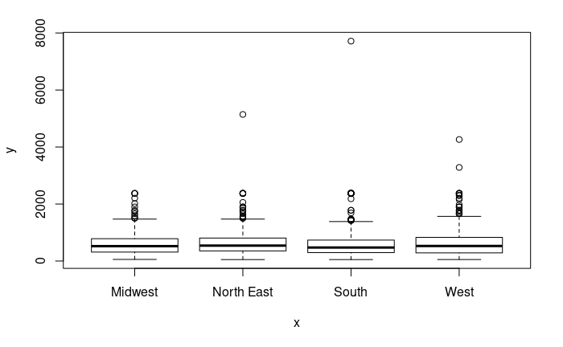

```r
# par(mfrow=c(2,2))
plot(uswages$location, uswages$wage)
```

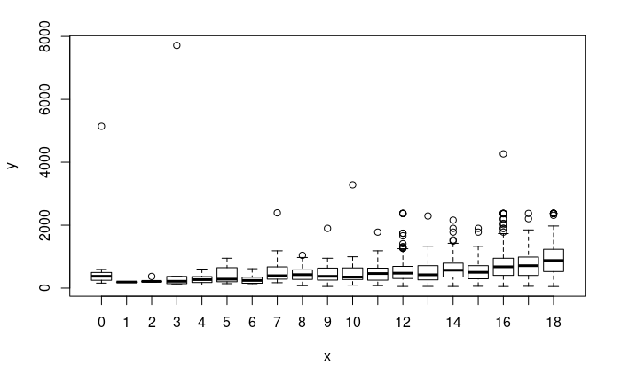

```r
plot(uswages$educ, uswages$wage)
```

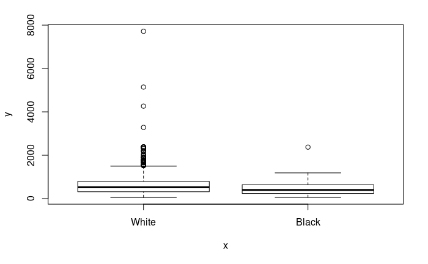

```r
plot(uswages$race, uswages$wage)
```

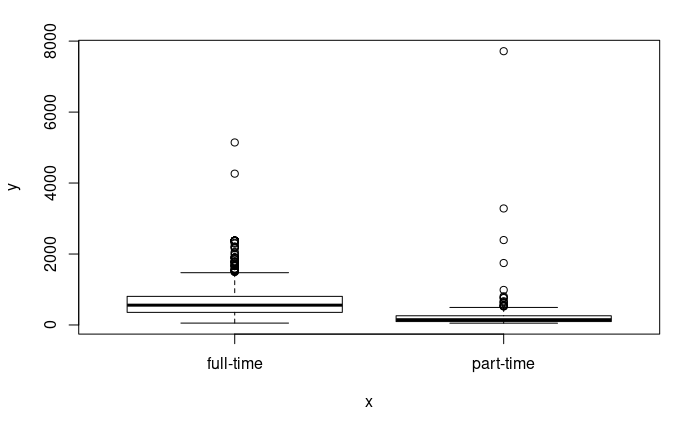

```r
plot(uswages$pt, uswages$wage)
```